# Spline Regression

Consider the dataset lidar available in the SemiPar package. This dataset is useful for helping to determine the amount of light received from two different laser sources by the amount of distance travelled before returning back to its source.

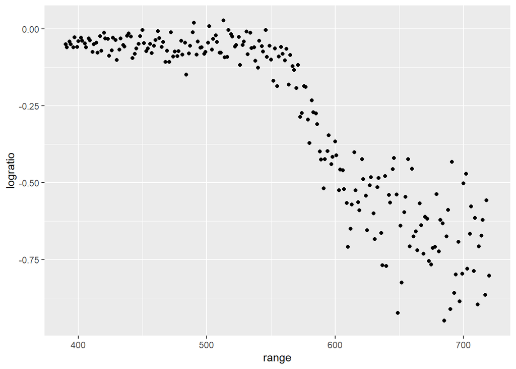

```r
library(tidyverse)
library(SemiPar)
data(lidar)
attach(lidar)
ggplot(data = lidar,aes(x=range,y=logratio)) +
  geom_point()
```

Clearly a linear model does not provide a good fit for the data, let’s see how well a quadratic or a cubic model fit the data.

Note: try adding polynomial terms to the dataset before transforming. This way you get predictions on the original scale.

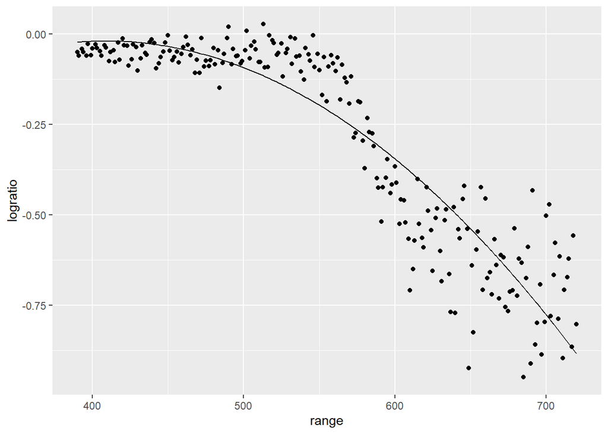

```r
mod_quad <- lm(logratio ~ range + I(range^2),lidar)

ggplot(data=lidar,aes(x=range,y=logratio))+
  geom_point() +
  geom_line(aes(x=range,y=fitted(mod_quad)))
```

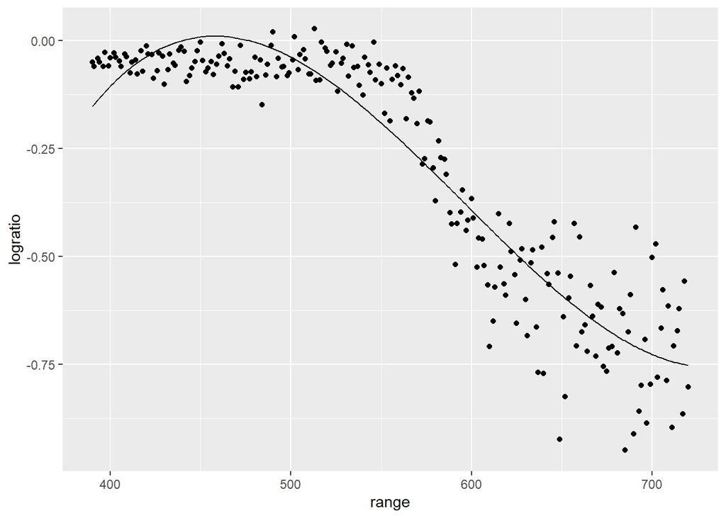

```r
mod_cube <- lm(logratio ~ range + I(range^2) + I(range^3),lidar)

ggplot(data=lidar,aes(x=range,y=logratio))+
  geom_point() +
  geom_line(aes(x=range,y=fitted(mod_cube)))
```

For the quadratic model, all of the range points between 500 and 575 are under-predicted.

For the cubic model, we still have the same underpredicting issue, and now, the points between 425 and 500 are overpredicting.

**Spline Regression**: A regression technique where the response variable is fit to a singular numeric explanatory variable (can be extended to multiple numeric explanatory variables) with piecewise polynomials set at predetermined points in the regression.

One of the more common spline techniques we will employ is a method of **B-spline** regression where the regression curve is fit using piecewise polynomials using Bezier curves as a basis function.

B-splines have two important parameters that are set *prior to* performing our data analysis.

- Degree ($d$): Highest term of the piecewise polynomials to be used (helps to control the smoothness of the regression curve)
- Knots ($K_n$): Internal breakpoints where the piecewise polynomials will be fit. The formula already places breakpoint ends at the minimum and maximum of $X$.

Let’s see how B-spline bases are calculated with a generic $X$ variables with values exclusively between 0 and 1.

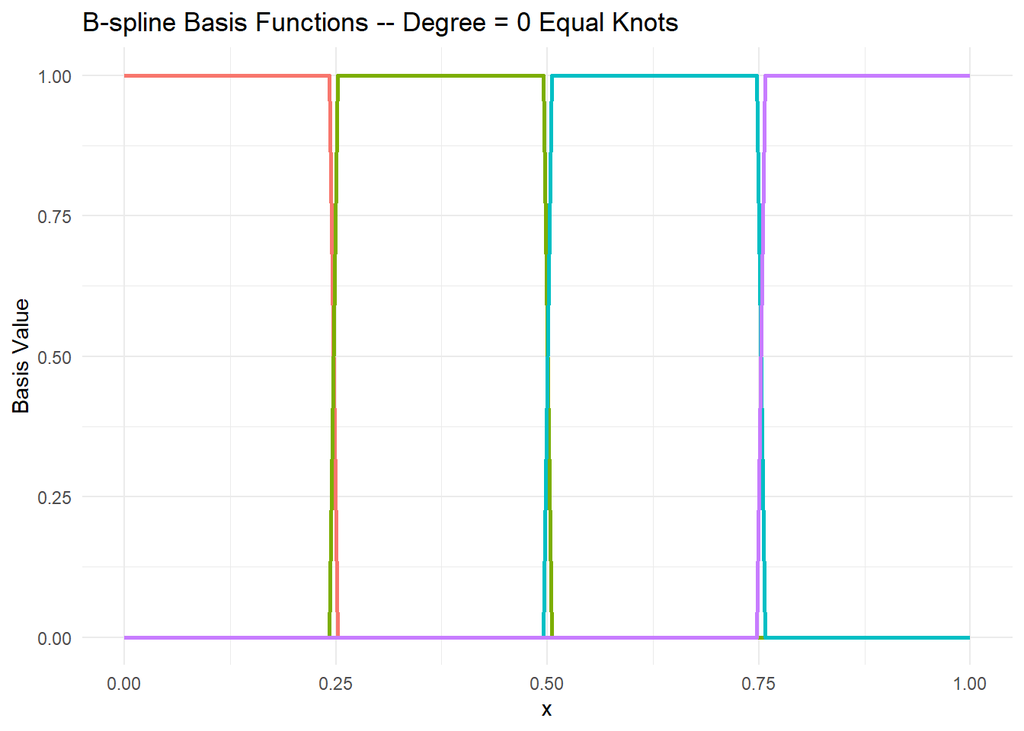

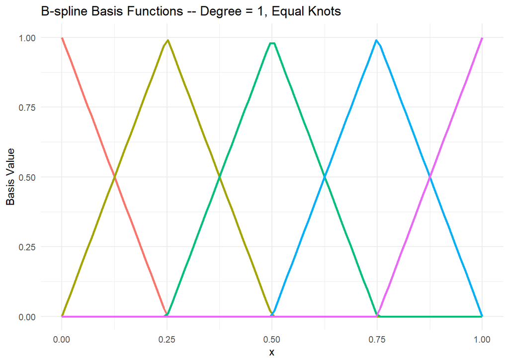

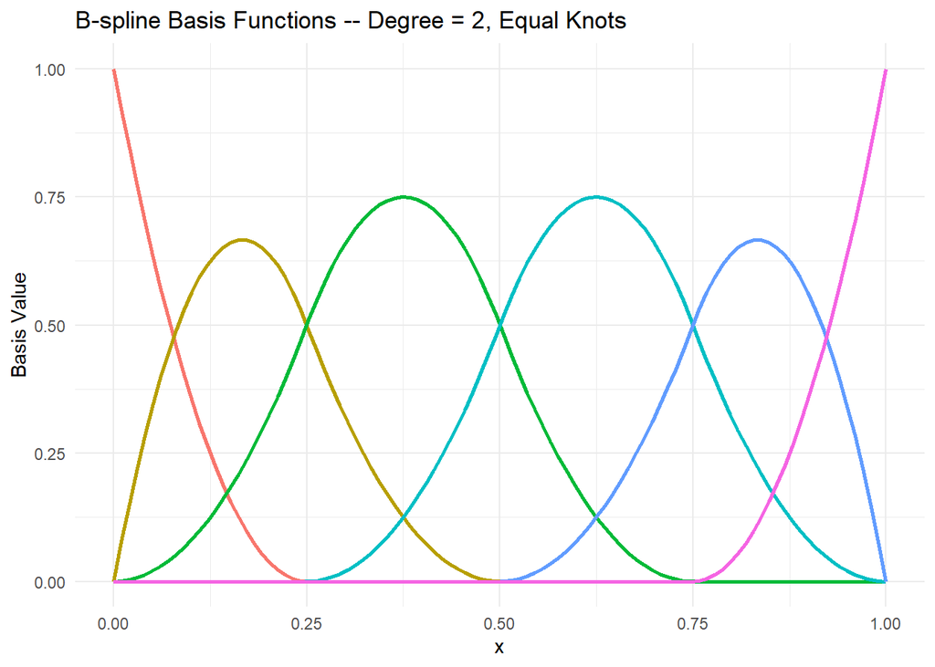

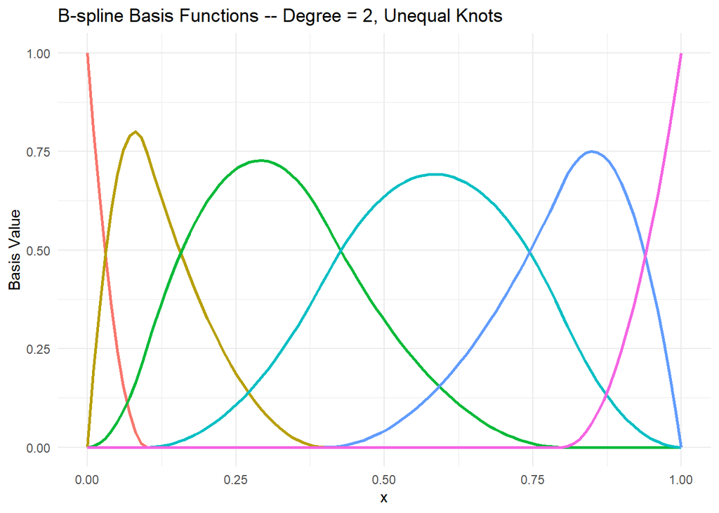

- Every time we add to the degree, we add an additional covariate in our regression analysis to control for an additional layer of smoothness
- We also need to add a covariate for every additional knot in our B-spline basis
- No matter what degree or knots you use, the values of the B-splines for each explanatory variable will always sum to 1.

Each curve represents the value of a new covariate to be used in our regression estimation. This creates $B(x_i)$, a vector of covariates created from the value of the explanatory variable $x_i$ with the specified degree and knots. $B$ is a function that maps $x_i$ to a simplex vector ( $\{x_1,\cdots,x_n: x_i \geq 0, \sum_{j=1}^n x_j = 1\}$)

$$\hat{\boldsymbol{\beta}} = (B'(\boldsymbol{X})B(\boldsymbol{X}))^{-1}B'(\boldsymbol{X})\boldsymbol{y}$$
$$\hat{\sigma}^2 = \frac{1}{n - k}(\boldsymbol{y} - B(\boldsymbol{X})\hat{\boldsymbol{\beta}})'(\boldsymbol{y} - B(\boldsymbol{X})\hat{\boldsymbol{\beta}})$$
where $k = d + |K_n| + 1$

$$\hat{\text{Var}}(\hat{\boldsymbol{\beta}}) = \hat{\sigma}^2(B'(\boldsymbol{X})B(\boldsymbol{X}))^{-1}$$

$$\hat{\mu}_{Y|X_0} = B(X_0) \hat{\boldsymbol{\beta}}$$

$$\hat{\text{Var}}(\hat{\mu}_{Y|X_0}) = B(X_0) \hat{\text{Var}}(\hat{\boldsymbol{\beta}})B'(X_0)$$

$$\text{100(1-}\alpha\text{)% confidence interval for }{\mu}_{Y|X_0}: \hat{\mu}_{Y|X_0} \pm t^*_{1-\frac{\alpha}{2},n-k} \sqrt{\hat{\text{Var}}(\hat{\mu}_{Y|X_0})}$$
$$\text{100(1-}\alpha\text{)% prediction interval for }{Y}_{X_0}: \hat{\mu}_{Y|X_0} \pm t^*_{1-\frac{\alpha}{2},n-k} \sqrt{\hat{\sigma}^2 + \hat{\text{Var}}(\hat{\mu}_{Y|X_0})}$$

Consider a regression on the lidar dataset with knots at each of the three quartiles of the dataset (to ensure group of piecewise polynomials has a roughly equal set of data points.)

### Degree = 0

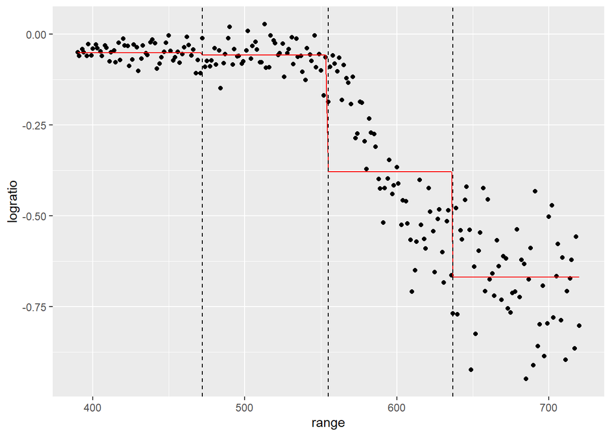

```r
library(splines2)
kn <- quantile(lidar$range,c(0.25,0.5,0.75))
# Calculate the B-spline basis functions
X0 <- bSpline(lidar$range,degree=0,knots=kn,intercept=TRUE)
# I want to use X as my model matrix, therefore, I do not want R to insert an intercept by default. The leading 0 prevents this.
mod_deg0 <- lm(logratio ~ 0 + X0,lidar)
ggplot(data = lidar,aes(x=range,y=logratio)) +
  geom_point() +
  geom_line(aes(x=range,y=fitted(mod_deg0)),colour='red') +
  # Create dashed vertical lines at each of the knots
  geom_vline(aes(xintercept = kn[1]),lty=2) +
  geom_vline(aes(xintercept = kn[2]),lty=2) +
  geom_vline(aes(xintercept = kn[3]),lty=2)
```

A Bspline basis with degree of 0 converts the numerical explanatory variable into a categorical variable separated by the knots!

### Degree = 1

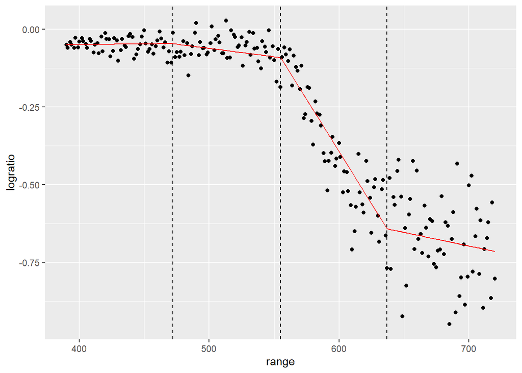

```r
X1 <- bSpline(lidar$range,degree=1,knots=kn,intercept = TRUE)

mod_deg1 <- lm(logratio ~ 0 + X1,lidar)
ggplot(data = lidar,aes(x=range,y=logratio)) +
  geom_point() +
  geom_line(aes(x=range,y=fitted(mod_deg1)),colour='red') +
  # Create dashed vertical lines at each of the knots
  geom_vline(aes(xintercept = kn[1]),lty=2) +
  geom_vline(aes(xintercept = kn[2]),lty=2) +
  geom_vline(aes(xintercept = kn[3]),lty=2)
```

Not only does the model fit a line in between each of the knots, but the structure of the B-spline basis functions ensure that the regression line is also continuous!

### Degree = 2

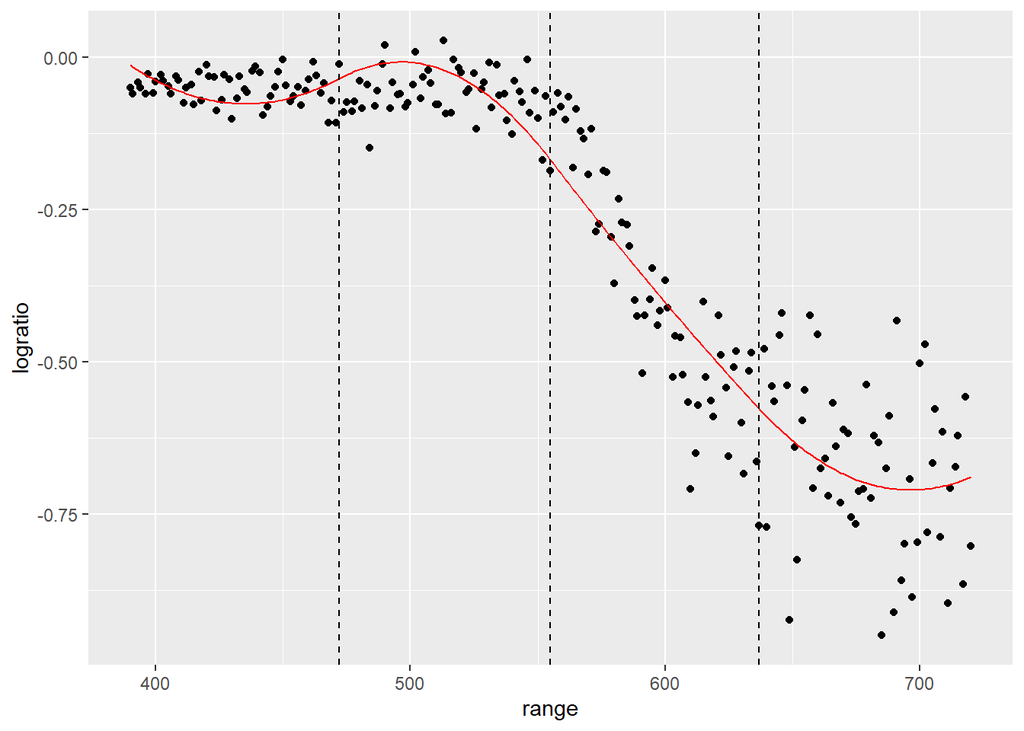

```r
X2 <- bSpline(lidar$range,degree=2,knots=kn,intercept=TRUE)

mod_deg2 <- lm(logratio ~ 0 + X2,lidar)
ggplot(data = lidar,aes(x=range,y=logratio)) +
  geom_point() +
  geom_line(aes(x=range,y=fitted(mod_deg2)),colour='red') +
  # Create dashed vertical lines at each of the knots
  geom_vline(aes(xintercept = kn[1]),lty=2) +
  geom_vline(aes(xintercept = kn[2]),lty=2) +
  geom_vline(aes(xintercept = kn[3]),lty=2)
```

The second degree provides a least squares regression function that is both continuous and first-order differentiable.

### Degree = 3

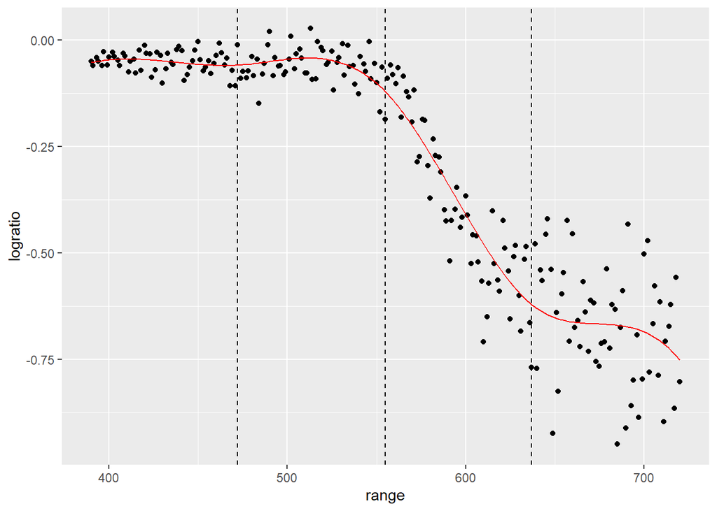

```r
X3 <- bSpline(lidar$range,degree=3,knots=kn,intercept=TRUE)

mod_deg3 <- lm(logratio ~ 0 + X3,lidar)
ggplot(data = lidar,aes(x=range,y=logratio)) +
  geom_point() +
  geom_line(aes(x=range,y=fitted(mod_deg3)),colour='red') +
  # Create dashed vertical lines at each of the knots
  geom_vline(aes(xintercept = kn[1]),lty=2) +
  geom_vline(aes(xintercept = kn[2]),lty=2) +
  geom_vline(aes(xintercept = kn[3]),lty=2)
```

The next covariate provides a function that is continuous and second-order differentiable.

- Again, all of the B-spline basis function are calculated using a specific algorithm based on the specified knots, degree, and (possibly Boundary knots)
- If we want to extrapolate outside of the minimum and maximum of the dataset, then set Boundary.knots to whatever you want to extrapolate to.

What we know:

- If $d = 0$, Bspline regression fits a step function at the knots
- If $d = 1$, Bspline regression fits a continuous function
- If $d \geq 2$, Bspline regression fits a continuous and $(d-1)^{th}$ differentiable function
- In most cases, never need to go beyond $d = 3$ to avoid overfitting.

Note: Can specify a specific degrees of freedom (df) instead of looking for the specific knots!

- This way you are guaranteed to have a continuous and 2nd order differentiable regression function while reducing the possibility of overfitting.

## Example

Create a B-spline regression model for the lidar dataset with $d = 3$ and $df = 7$

```r
X <- bSpline(lidar$range,df=7,degree=3,intercept = TRUE)
mod <- lm(logratio ~ 0 + X,lidar)
summary(mod)
```

```
Call:
lm(formula = logratio ~ 0 + X, data = lidar)

Residuals:
      Min        1Q    Median        3Q       Max
-0.279531 -0.035481  0.000573  0.039349  0.241248

Coefficients:
   Estimate Std. Error t value Pr(>|t|)
X1 -0.05327    0.03362  -1.584  0.11458
X2 -0.02937    0.03779  -0.777  0.43784
X3 -0.10341    0.03688  -2.804  0.00551 **
X4  0.05001    0.03128   1.599  0.11133
X5 -0.81959    0.03689 -22.220  < 2e-16 ***
X6 -0.60859    0.03823 -15.919  < 2e-16 ***
X7 -0.75208    0.03447 -21.815  < 2e-16 ***
---
Signif. codes:  0 '***' 0.001 '**' 0.01 '*' 0.05 '.' 0.1 ' ' 1

Residual standard error: 0.08167 on 214 degrees of freedom
Multiple R-squared:  0.9607,    Adjusted R-squared:  0.9594
F-statistic: 746.8 on 7 and 214 DF,  p-value: < 2.2e-16
```

- Calculate and interpret a 95% confidence interval for the logratio of light received when the range is 705.
- Calculate and interpret a 95% confidence interval for the logratio of light received when the range is 402.
- While BSpline regression models help to relax the assumption of linearity between $X$ and $Y$, because we will have normally distributed errors, we still need to check the assumptions of homoscedasticity and normality. Determine if the assumptions of homoscedasticity and normality are violated. If they are violated, suggest a method to fix this issue.

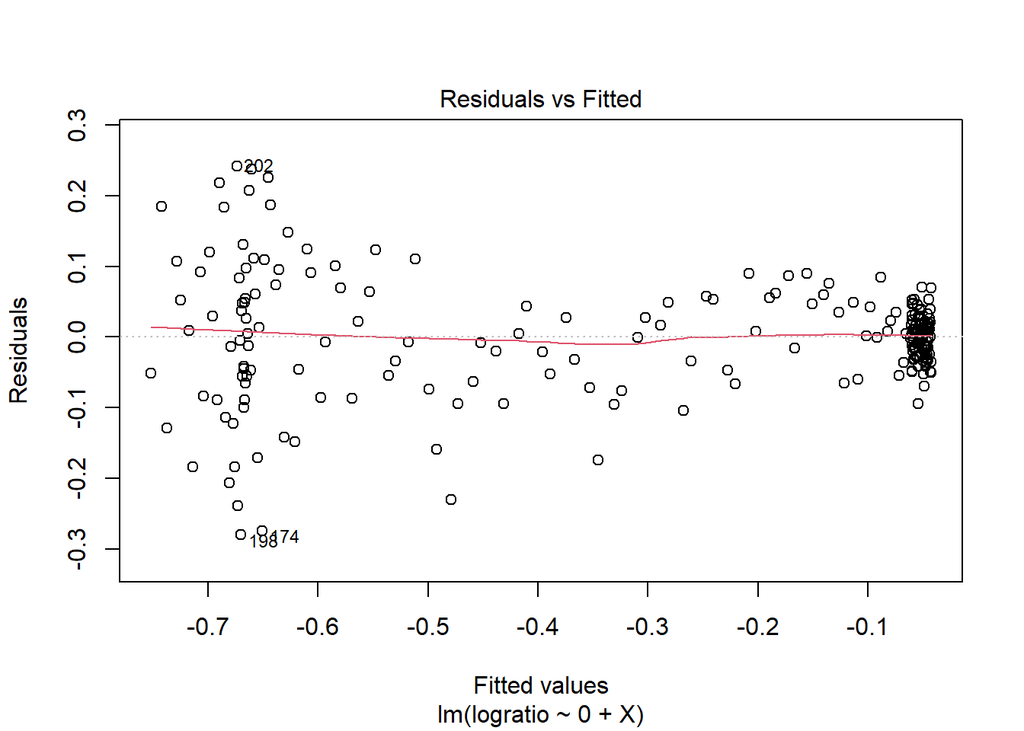

```r
plot(mod,1)
```

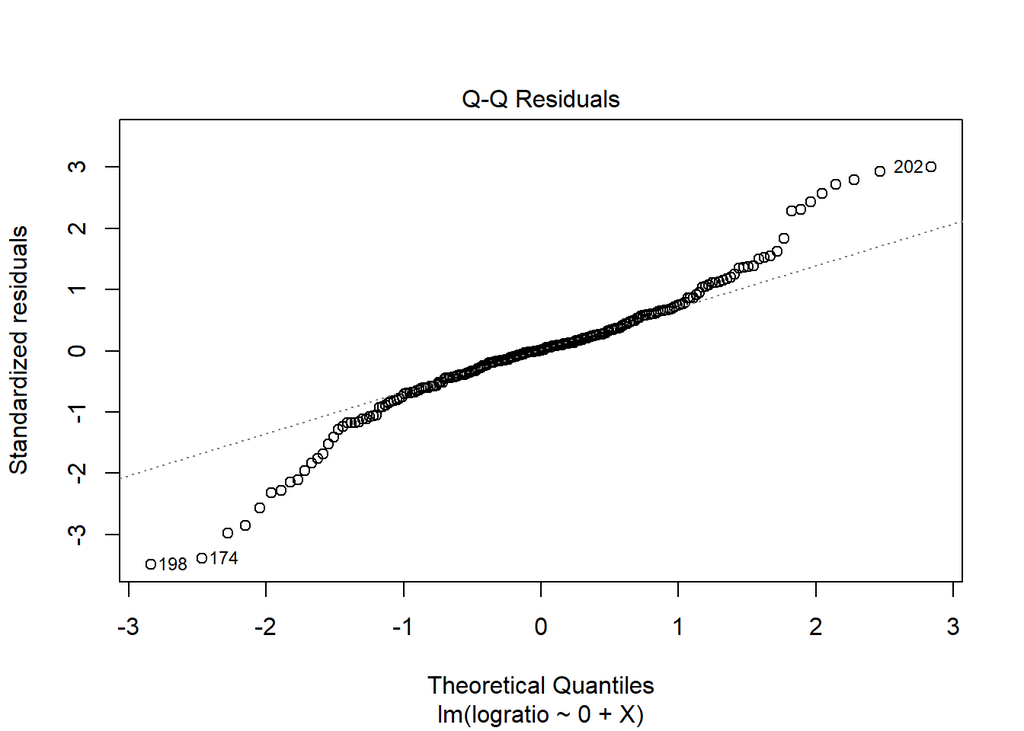

```r
plot(mod,2)
```

```r
library(lmtest)
bptest(mod)
```

```
    studentized Breusch-Pagan test

data:  mod
BP = 58.649, df = 6, p-value = 8.465e-11
```

```r
ks.test(rstandard(mod),"pnorm")
```

```
    Asymptotic one-sample Kolmogorov-Smirnov test

data:  rstandard(mod)
D = 0.086967, p-value = 0.07066
alternative hypothesis: two-sided
```

Based on the tests, assumption of normality is not violated, but the assumption of homoscedasticity is. This means that I would try weighted B-spline regression.